# SimuPLNmissing

```r
library(PLNmodels)
library(EMtree)
library(LITree)
```

```r
library(mvtnorm)
library(MASS)
library(saturnin)
library(Matrix)
library(ggplot2)
library(tictoc)
library(tibble)
library(ROCR)
library(mclust)
library(useful)
library(dplyr)
library(rlist)
library(tidyr)
source('/Users/raphaellemomal/these/R/codes/missingActor/LiTree/functions-estimation.R')
source('/Users/raphaellemomal/these/R/codes/missingActor/LiTree/functions-simulation.R')
```

# Data

```r
set.seed(7)
p=30
n=300
Data=gener.data(counts = FALSE,p=p,n=n,type="erdos",prop=5/p)
```

```
## [1] "Erdös-Renyi graph built"
##
## distance Km-Ko = 0.00357150044046473
```

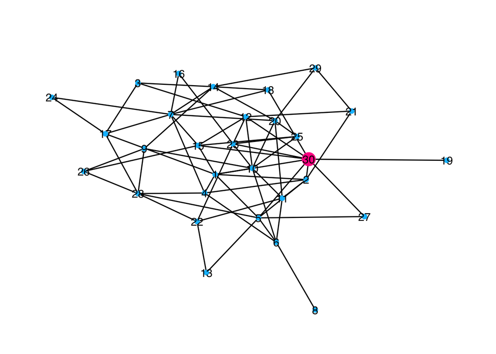

```r
omega=Data$omega
adjmat=1*(omega!=0)
omega_obs=Data$omegaO
sigma_obs=Data$sigmaO
trueClique=Data$clique
compute_SNR(omega,Data$hidden)
```

```
## [1] 0.002875161
```

```r
min(eigen(omega)$values)
```

```
## [1] 0.106462
```

# Initialization

The function `init.mclust` takes the covariance matrix as input, and apply a model of mclust which uses some background noise. That way, we can look for a cluster without forcing the rest of the data to form a second cluster. The clustering is done on the space built with the first two eigen vectors of the covariance matrix. To solve the issue of the sign in this particular space, points are converted in polar coordinates and recoded with $\theta \in [0,\pi]$ an $\rho$ real valued.

```r
initviasigma=init.mclust(sigma_obs,title="Sigma",trueClique = trueClique,n.noise=p*3+5)
```

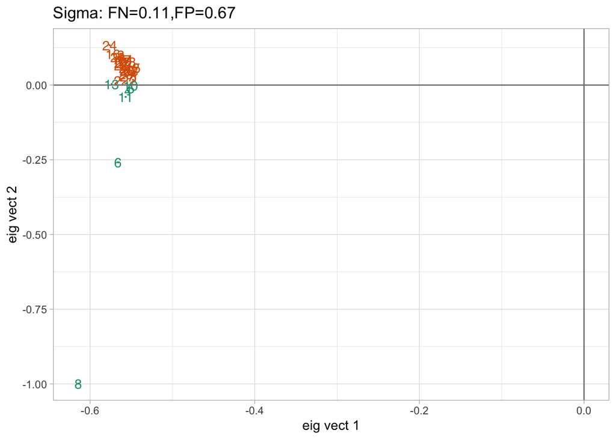

```r
initviaomega= init.mclust(omega_obs,title="Omega",trueClique = trueClique,n.noise=p*3+5)
```

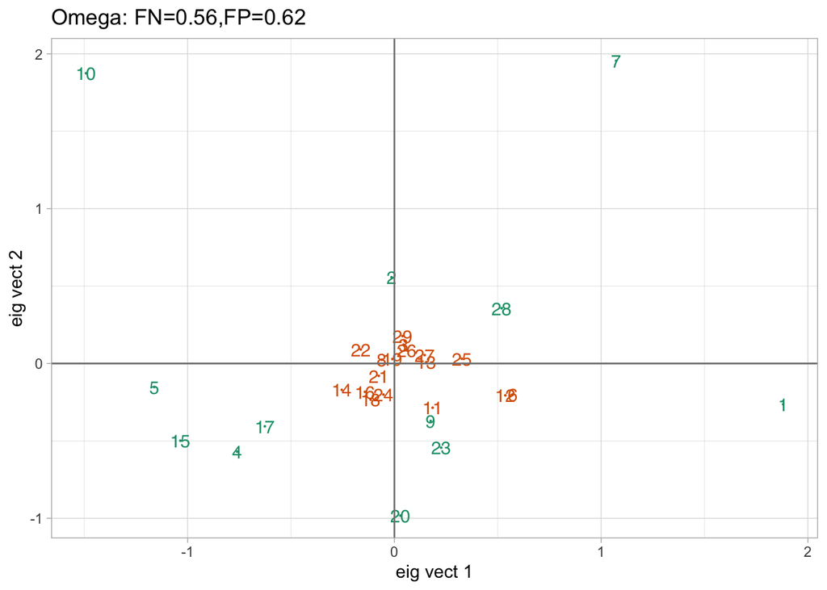

```r
trueClique
```

```
## [1]  1  2  5 12 15 18 19 23 27
```

We design two types of initialization, one using `mclust` and another using function `findCliques`

```r
sample=FALSE
boolomega=FALSE
if(length(initviasigma)<3) boolomega=TRUE
if(length(initviasigma)<3 && length(initviaomega)<3){sample=TRUE; boolomega=FALSE}
init1=list(initviasigma)
if(boolomega) init1=list(initviaomega)
if(sample){
  init1=list(order(colSums(sigma_obs),decreasing=TRUE)[1:3])
  print(init1)
}
init2=findCliques(sigma_obs,1)

initial.param<-initEM(sigma_obs,n=n,cliquelist = init2,pca=TRUE)
K2=initial.param$K0
Sigma2=initial.param$Sigma0


initial.param<-initEM(sigma_obs,n=n,cliquelist = init1,pca=TRUE)
K1=initial.param$K0
Sigma1=initial.param$Sigma0
```

# Inferences

The network is inferred using the `treeAgr.EM`function of Robin et. al 2018 (recoded as `EMtreeMissing`). The two different initializations are tested, as well as a “naive”" version of EMtree, which is EMtree run on a covariance matrix which consists in the observed covariance matrix with an additional dimension and “1” on the diagonal (0 elsewhere on the added dimension row and column).

```r
tic()
inftreeAgr1 = EMtreeMissing(S=sigma_obs, k=1, K0 = K1, Sigma0 = Sigma1, pii=0.5, n=n,
                            max.iter = 200, eps = 0.1,method = "saturnin")
```

```
## [1] "Convergence reached"
```

```r
toc()
```

```
## 31.933 sec elapsed
```

```r
tic()
inftreeAgr2 = EMtreeMissing(S=sigma_obs, k=1, K0 = K2, Sigma0 = Sigma2, pii=0.5, n=n,
                            max.iter = 200, eps = 0.1,method = "saturnin")
```

```
## [1] "Convergence reached"
```

```r
toc()
```

```
## 29.308 sec elapsed
```

[figure not shown]

```r
# EMtree : proba calculées à partir du Sigma reconstitué par treeAgrEM
# EMtree naif: ajout d'une ligne et colonne à sigma_obs, avec 1 sur la diagonale
infEMtree=EMtree_corZ(CovZ=inftreeAgr1$Sigma,n = n)$edges_prob
```

```
##
## Likelihoods: 150.0382 , 150.1234 , 150.1237 , 150.1238 , 150.1239 ,
## Convergence took 0.47 secs  and  5  iterations.
## Likelihood difference = 6.214267e-05
## Betas difference = 2.776027e-09
```

```r
infEMtreeNaif=EMtree_corZ(CovZ=rbind(cbind(sigma_obs,rep(0,p-1)),c(rep(0,p-1),1)),n = n)$edges_prob
```

```
##
## Likelihoods: 103.945 , 104.0077 , 104.0129 , 104.0149 , 104.0153 , 104.0155 , 104.0158 , 104.0158 ,
## Convergence took 0.32 secs  and  8  iterations.
## Likelihood difference = 8.04144e-05
## Betas difference = 2.780843e-09
```

# Results

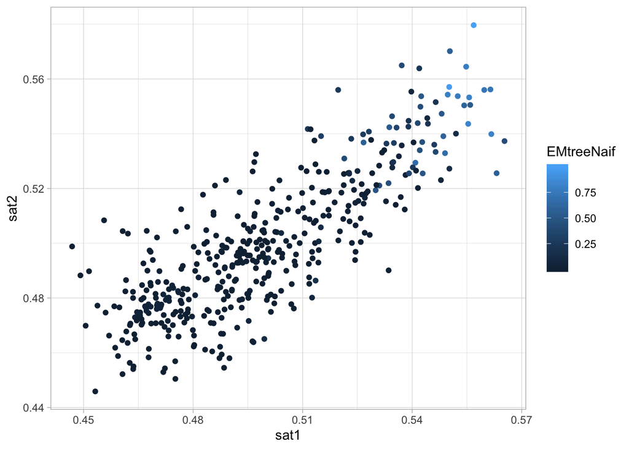

```r
probdata=data.frame("sat1"=F_Sym2Vec(inftreeAgr1$alpha),
                    "sat2"=F_Sym2Vec(inftreeAgr2$alpha),
                    "EMtree"=F_Sym2Vec(infEMtree),
                    "EMtreeNaif"=F_Sym2Vec(infEMtreeNaif))

probdata %>%as_tibble() %>%
  ggplot(aes(sat1,sat2, color=EMtreeNaif))+geom_point()+theme_light()
```

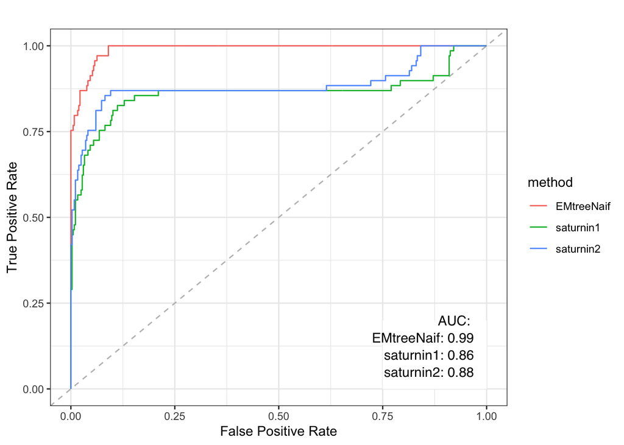

```r
fun.auc.ggplot(Listpred = list( EMtreeNaif=infEMtreeNaif,#EMtree=infEMtree,
                                saturnin1=inftreeAgr1$alpha,
                                saturnin2=inftreeAgr2$alpha),
               obs=omega, title="")
```

# Used functions

```r
F_Vec2Sym <- function(A.vec){
  n = (1+sqrt(1+8*length(A.vec)))/2
  A.mat = matrix(0, n, n)
  A.mat[lower.tri(A.mat)] = A.vec
  A.mat = A.mat + t(A.mat)
  return(A.mat)
}
F_Sym2Vec <- function(A.mat){
  return(A.mat[lower.tri(A.mat)])
}

#EMtree from a covariance matrix instead of a PLN object
EMtree_corZ<-function(CovZ,n,  maxIter=30, cond.tol=1e-10, verbatim=TRUE, plot=FALSE){
  CorZ=cov2cor(CovZ)
  p = ncol(CorZ)
  alpha.psi = Psi_alpha(CorZ, n, cond.tol=cond.tol)
  psi = alpha.psi$psi
  beta.unif = matrix(1, p, p); diag(beta.unif) = 0; beta.unif = beta.unif / sum(beta.unif)
  FitEM = FitBetaStatic(beta.init=beta.unif, psi=psi, maxIter = maxIter,
                        verbatim=verbatim, plot=plot)
  return(FitEM)
}

init.mclust<-function(S,nb.missing=1, n.noise=50,plot=TRUE, title="",trueClique=NULL){
  X<-data.frame(t(t(eigen(S)$vectors[,1:2])*sqrt(eigen(S)$values[1:2])))

  p=nrow(X)+nb.missing
  b=apply(X, 2, range)
  poissonNoise<-apply(b, 2, function(x,n=n.noise){
    runif(n,min=x[1]-0.1, max=x[2]+0.1)
  })
  data=rbind(X, poissonNoise)
  noiseInit<-sample(c(T,F), size=nrow(X)+n.noise, replace=T, prob=c(3, 1))
  datapolar=cart2pol(x=data[,1],y=data[,2])[,1:2]
  datapolar=datapolar %>% mutate(theta2=ifelse(theta>pi,theta-pi,theta)) %>% select(r,theta2)
  newdata=pol2cart(datapolar$r,datapolar$theta2)[,1:2]
  clust=Mclust(data=newdata,initialization = list(noise=noiseInit),G=nb.missing)
  groups<-map(clust$z)
  res<-which(groups==1)[which(groups==1)<=nrow(X)]
  if(plot){
    if(!is.null(trueClique)){
      #False positives rate
      N=setdiff(1:p,trueClique)
      FP=sum(res%in%N)/length(N)
      # False negatives rate
      FN=sum(setdiff(1:p,res)%in%trueClique)/length(trueClique)
      title=paste0(title,":"," FN=", round(FN,2),",FP=",round(FP,2))
    }

    g= ggplot(X,aes(X1,X2, label=rownames(X),color=rownames(X)%in%res))+geom_point(size=0.1)+
      theme_light()+geom_text()+labs(x="eig vect 1",y="eig vect 2", title=title)+
      guides(color=FALSE)+scale_color_brewer(palette="Dark2")+
      geom_hline(yintercept=0, color="gray50")+geom_vline(xintercept=0, color="gray50")
    print(g)
  }
  return(res)
}
fun.auc.ggplot <- function(Listpred, obs, title){
  #require(ROCR)
  indices_nuls<-which(obs==0)
  label<-matrix(1,nrow=nrow(obs),ncol=ncol(obs))
  label[indices_nuls]<-0
  ROC_auc=c()
  plotdat=lapply(seq_along(Listpred),function(x){
    pred=Listpred[[x]]
    prediction<-prediction(as.vector(pred[upper.tri(pred)]),as.vector(label[upper.tri(label)]))
    obs<-as.vector(label[upper.tri(label)])
    # Run the AUC calculations
    ROC_perf <- performance(prediction,"tpr","fpr")

    ROC_auc <<-c(ROC_auc, round(performance(prediction,"auc")@y.values[[1]],digits=2))

    # Make plot data
    res <- data.frame(FP=ROC_perf@x.values[[1]],TP=ROC_perf@y.values[[1]], method=names(Listpred)[x] )

  })
  plotdat=do.call(rbind, plotdat)
  # Plot the curve

  ggplot(plotdat, aes(x=FP,y=TP)) +
    geom_abline(intercept=0,slope=1,linetype="dashed",color="grey") +
    geom_line(aes(color=method)) +
    scale_x_continuous("False Positive Rate", limits=c(0,1)) +
    scale_y_continuous("True Positive Rate", limits=c(0,1)) +
    geom_polygon(aes(x=X,y=Y), data=data.frame(X=c(0.75,1,1,0.75),Y=c(0,0,0.2,0.2)), fill="white") +
    annotate("text",x=0.97,y=0.2,label=paste0("AUC: "),hjust=1) +
    annotate("text",x=0.97,y=0.15,label=paste0(names(Listpred)[1],": ",ROC_auc[1]),hjust=1) +
    annotate("text",x=0.97,y=0.1,label=paste0(names(Listpred)[2],": ",ROC_auc[2]),hjust=1) +
    annotate("text",x=0.97,y=0.05,label=paste0(names(Listpred)[3],": ",ROC_auc[3]),hjust=1) +
    theme(legend.position="none", plot.title=element_text(vjust=2,hjust = 0.5)) +
    labs(title=title)+
    theme_bw()
}

compute_SNR<-function(K, indexmissing){
  H=indexmissing ; p=ncol(K)
  O=(1:p)[-H]
  num=norm(K[O,H]%*%K[H,O]/K[H,H],type='2')^2
  denom=norm(K[O,O],type='2')^2
  return(num/denom)
}
amplify_cor<-function(K,indexmissing,eps){
  H=indexmissing ; p=ncol(K)
  O=(1:p)[-H]
  newK=eps*K
  newK[O,O]=K[O,O]
  newK[H,H]=eps*K[H,H]
  return(newK)
}
amplify_diag<-function(K,v){
  newK<-K+diag(v, ncol(K))
  return(newK)
}
setEpsi<-function(K,indexmissing, plot=FALSE){
  eps<-1
  v<-(-0.1)
  L=list(c(compute_SNR(K,indexmissing),eps,v))
  print(min(eigen(K)$values))

  while(compute_SNR(K,indexmissing)<1){

    if(min(eigen(K)$values)>0){

      while(min(eigen(K)$values)>0){
        eps=eps+0.01
        K=amplify_cor(K,indexmissing,eps)
      }

      L=list.append(L,c(compute_SNR(K,indexmissing), eps, v))

    }else{

      while(min(eigen(K)$values)<=0){
        v=v+0.01
        K=amplify_diag(K,v)
      }

      L=list.append(L,c(compute_SNR(K,indexmissing), eps, v))
    }

  }
  L=do.call(rbind,L)
  colnames(L)=c("SNR","Epsilon","Lambda")
  cat(paste0("\nfinal SNR=",round(compute_SNR(K,indexmissing),3),", final min eig ",min(eigen(K)$values),", for eps=",eps," and v=",v))
  if(plot){
    g= L%>% as_tibble() %>% gather(parameter,value,-SNR) %>%
      ggplot(aes(value,SNR))+geom_point()+geom_line()+facet_wrap(~parameter,scales="free")+
      theme_light()
    print(g)
  }
  return(list(K=K,values=L))
}

gener.data<-function(p=20,n=200,counts=FALSE, type="scale-free", v=0.001,plot=TRUE){
  data=data_from_scratch(type = type,p = p,n = n,signed = TRUE,prob = 5/p,v = v)
  omega=data$omega


  hidden=which.max(diag(omega)) #on cache le noeud de plus fort degré
  omega=setEpsi(omega,hidden, plot=TRUE)$K
  sigma=solve(omega)
  # les voisins du noeuds qu'on cache
  trueClique=which(omega[hidden,-hidden]!=0)

  #comptages ou non
  if(counts){
    counts=data$data
    counts_obs=counts[,-hidden]
    sigma_obs=PLN(counts_obs~1)$model_par$Sigma
  }else{
    data=rmvnorm(n,sigma=sigma)
    data_obs=data[,-hidden]
    sigma_obs=cov(data_obs)
  }
  omega_obs=solve(sigma_obs)
  if(plot){
    G=draw_network(abs(omega),groupes=1*(diag(omega)==diag(omega)[hidden]),
                   layout="nicely",curv=0,nb=2,pal="black",nodes_label = 1:p)$G
    print(G)
  }
  return(list(sigmaO=sigma_obs, omegaO=omega_obs,omega=omega,clique=trueClique, hidden=hidden))
}
```